# Macroeconomics Q4

Kenji Sato  
2016-12-07

### Welcome to Macroeconomics (Q4)!

- Name:
  - **Kenji Sato**
  - PLEASE DO NOT call me “Professor!”
  - “Kenji” or “Sato-*san*” are preferable. “Sato-*sensei*” is acceptable.
- Fields of Interest:
  - Macroeconomic Dynamics
  - Economics of Innovation
  - Comparative Statics/Dynamics
- For course mechanics, take a look at the handout.

### Welcome to Macroeconomics (Q4)!

- Office hours
- Textbook
- Schedule
- Grading
- Course websites

### Welcome to Macroeconomics (Q4)!

- Macroeconomics is a study of such aggregate economic evariables as …
  - Gross Domestic Product (GDP)
  - Growth Rate
  - Business Cycles
  - Unemployment Rate
  - Inflation Rate
  - Income Inequality

### Welcome to Macroeconomics (Q4)!

- In this course, you are going to study …
  - basic machinery of graduate-level macroeconomics;
  - how to code computer programs to compare theory with data;
  - **theories** on how GDP and growth rates move.
- To learn how to solve growth models, you will need to learn
  - differential equations and difference equations, and
  - dynamic optimization.

### Limit

- Because of the limited time, this course will focus on a study of economic growth theory.
  - The **foundation** of modern macroeconomic research.
  - If we have time, we will move on to the study of innovation or business cycles.
  - No money, unemployment or inequality.

### Call for Enrollment

- You are **highly recommended** to take more advanced/applied courses together with this course.
  - **Inequality and Macroeconomics** by Professor Dr. Reto Föllmi, from January 26 to 31.
  - Please go to Kyoumu for enrollment!

### Programing Languages

After taking Watkins's courses, I believe you are familiar with R programing language.

- I will also use R when I show you data.
  - Highly recommended to type yourself to reproduce plots.
  - Building muscle memory is a necessary part of climbing up the learning curve.
- Sometimes I will use Python for performing simulations.
  - Because I like Python.

### Penn World Table, Ver. 8

- Feenstra, Inklaar and Timmer (2015) “The next generation of the Penn World Table,” *American Economic Review* 105(10). 3150–82.

```r
library(readstata13)
library(dplyr)
library(ggplot2)
pwt8 = read.dta13("pwt90.dta")
```

### Penn World Table, Ver. 8 (cont'd)

You can easily analyse the data with R + dplyr.

```r
pwt8 %>%
  filter(country == "Japan", year > 2010) %>%
  mutate(rgdp_per_capita = rgdpo / pop) %>%
  select(year, rgdp_per_capita)
```

```
  year rgdp_per_capita
1 2011        34979.34
2 2012        35191.24
3 2013        35476.46
4 2014        35566.22
```

Unit: 2011US$

Note: With R it is difficult to see the descriptive labels that STATA variables have. Install gretl to work around.

### Real GDP per capita: Data processing

We are interested in evolution of real GDP per person (per capita). Becase it is a nice statistic to measure the standard of living for a country.

Let's compare those of three countries since 1980.

```r
rgdp <- pwt8 %>%
  filter(countrycode %in% c("JPN","USA", "KOR"),
         year > 1980) %>%
  mutate(rgdp_pc = rgdpo / pop) %>%
  select(country, year, rgdp_pc) %>%
  as.data.frame
```

### Real GDP per capita: Plotting

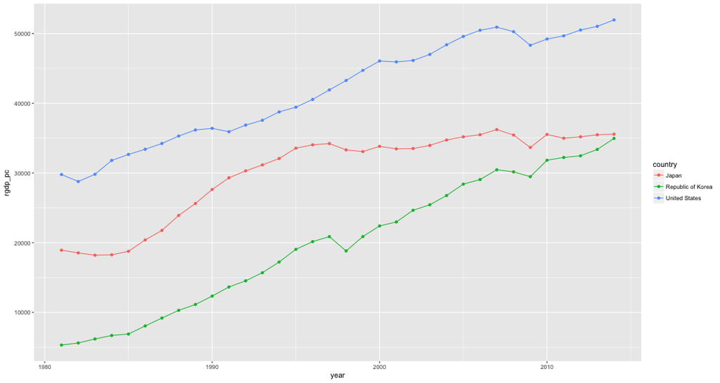

```r
ggplot(rgdp, aes(x=year, y=rgdp_pc, color=country)) +
  geom_point() + geom_line(aes(group=country))
```

### GDP Growth

When studying the growth rates, semi-log scale is helpful.

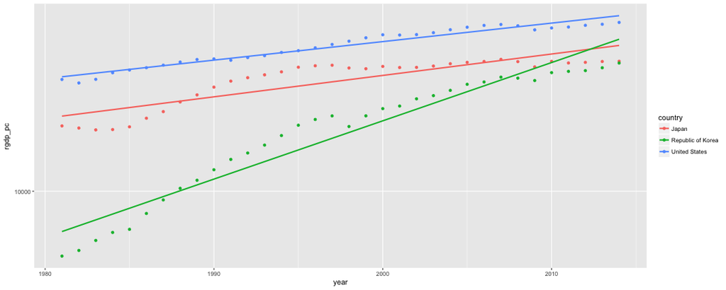

```r
rgdp %>% ggplot(aes(x=year, y=rgdp_pc, color=country)) + geom_point() +
         scale_y_log10() +  # Plot in semi-log scale
         geom_smooth(method = "lm", se = FALSE)
```

### Why log-scale?

\[ \begin{aligned} & \text{Gross annual growth rate from 2000 to 2010} \\ &= \left(\frac{GDP_{2010}}{GDP_{2000}}\right)^{1/10} \end{aligned} \]

And so, ….

\[ \begin{aligned} & \log (\text{Gross annual growth rate from 2000 to 2010}) \\ &= \frac{\log GDP_{2010} - \log GDP_{2000}}{2010 - 2000} \end{aligned} \]

The slopes of the lines you observed in the semi-log plot correspond to the growth rates of the countries.

### Change in growth rates.

The growth rates change over time.

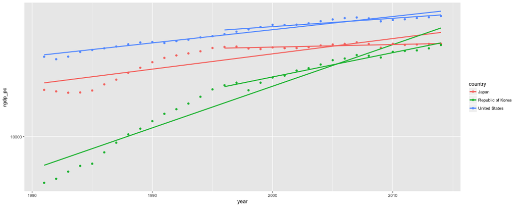

```r
rgdp %>% ggplot(aes(x=year, y=rgdp_pc, color=country)) + geom_point() +
         scale_y_log10() +  # Plot in semi-log scale
         geom_smooth(method="lm", se=FALSE) +
         geom_smooth(data=filter(rgdp, year > 1995),
                     method="lm", se=FALSE)
```

### Observations and Questions

- There is a growing trend in per capita GDP.
  - What drives the growth?
- The US growth rate seems to be very stable.
  - What determines the growth rate?
  - Is the long-run stability of the growth rate common to all countries?
- Korea experienced rapid growth recently but seems to be slowing down.
  - Is this a common feature? Will every rapidly growing country slow down its growth?
  - Or, will Korea accelerate the growth again?

### Cross Country Differences

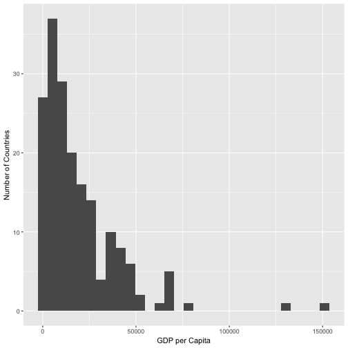

```r
cross_country <- pwt8 %>% filter(year == 2014) %>%
  mutate(rgdp_pc = rgdpo / pop) %>%
  select(countrycode, rgdp_pc) %>% as.data.frame

ggplot(cross_country, aes(x=rgdp_pc)) +
  geom_histogram() +  labs(x="GDP per Capita", y="Number of Countries")
```